# Probability of freedom

Thomas Rosendal

# Simple freedom calculation

## Scenario

You have a population of 10000 herds of which 500 are tested per year using a test that has a herd sensitivity (HSe) of 20%; all of these tests were negative. You need to calculate the annual surveillance system sensitivity (SysSe) and the probability that the disease has a lower than 1% prevalence (dp) in the population of herd over time given a prior assumption that the probability of the disease being absent from the population is 50% (prior_pr). You also assume that the annual cumulative probability of introduction to the population is 1% (prob_intro). This programme was ongoing from 2012 to 2020.

## Calculate system sensitivity

```r
library(freedom)

Hse <- rep(0.2, 500)
dp <- rep(0.01, 500)
SysSe <- sysse(dp, Hse)
```

## Temporal discounting

The surveillance system has a sensitivity of detecting the disease at a prevalence of greater than of equal to 0.01 is 0.6324887 for 1 year. We can then use this to calculate the probability of freedom of disease over time.

```r
prior_pr <- 0.5
prob_intro <- 0.01

pr_free <- data.frame(year = 2012:2020,
                      prior_fr = NA,
                      post_fr = NA,
                      stringsAsFactors = FALSE)
## At the beginning of the first year the probability of freedom is just
## the prior.

pr_free$prior_fr[1] <- prior_pr
pr_free$post_fr[1] <- post_fr(pr_free$prior_fr[1], SysSe)

## Then we use the temporal discouting proceedure to calculate the subsequent
## years:

for (i in seq(2, nrow(pr_free))) {
    pr_free$prior_fr[i] <- prior_fr(pr_free$post_fr[i - 1], prob_intro)
    pr_free$post_fr[i] <- post_fr(pr_free$prior_fr[i], SysSe)
}
```

## Plot results

```r
pr_free
```

```
##   year  prior_fr   post_fr
## 1 2012 0.5000000 0.7312554
## 2 2013 0.7239429 0.8770845
## 3 2014 0.8683136 0.9472066
## 4 2015 0.9377345 0.9761786
## 5 2016 0.9664168 0.9873900
## 6 2017 0.9775161 0.9916177
## 7 2018 0.9817015 0.9931964
## 8 2019 0.9832644 0.9937837
## 9 2020 0.9838458 0.9940019
```

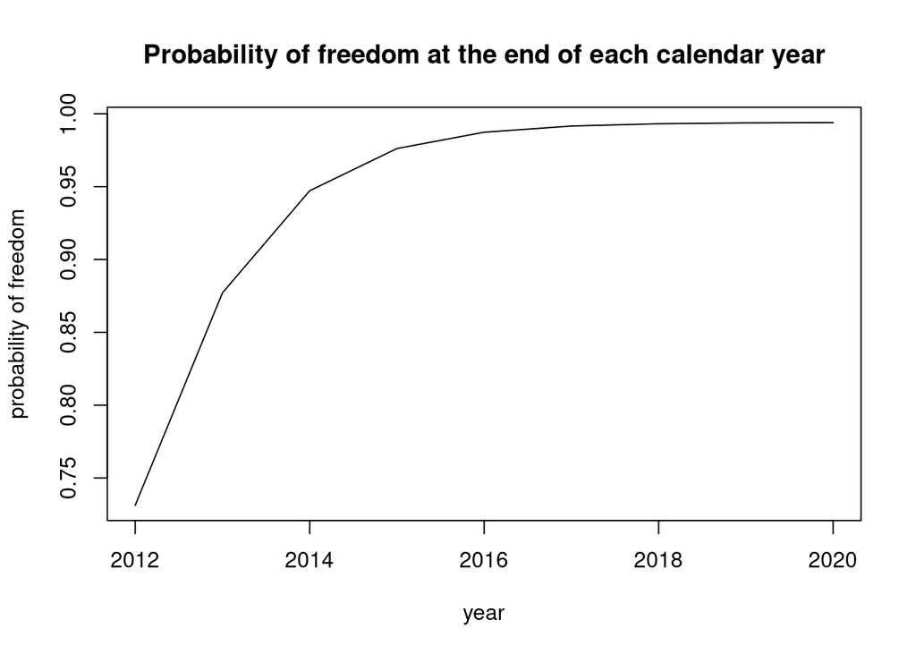

```r
plot(x = pr_free$year,
     y = pr_free$post_fr,
     type = "l",
     xlab = "year",
     ylab = "probability of freedom",
     main = "Probability of freedom at the end of each calendar year")
```